# Attractiveness and wage

Evgeniy Riabenko

## Problem formulation

1260 study participants provided the following data:

- hourly wage in $;
- working experience in years;
- education in years;
- attractiveness on a scale from 1 to 5;
- binary features: sex, marital status, health (good/bad), ethnicity (white/black), union membership indicator, service industry indicator.

We need to estimate the influence of attractiveness on wage while adjusting for other factors.

Data:

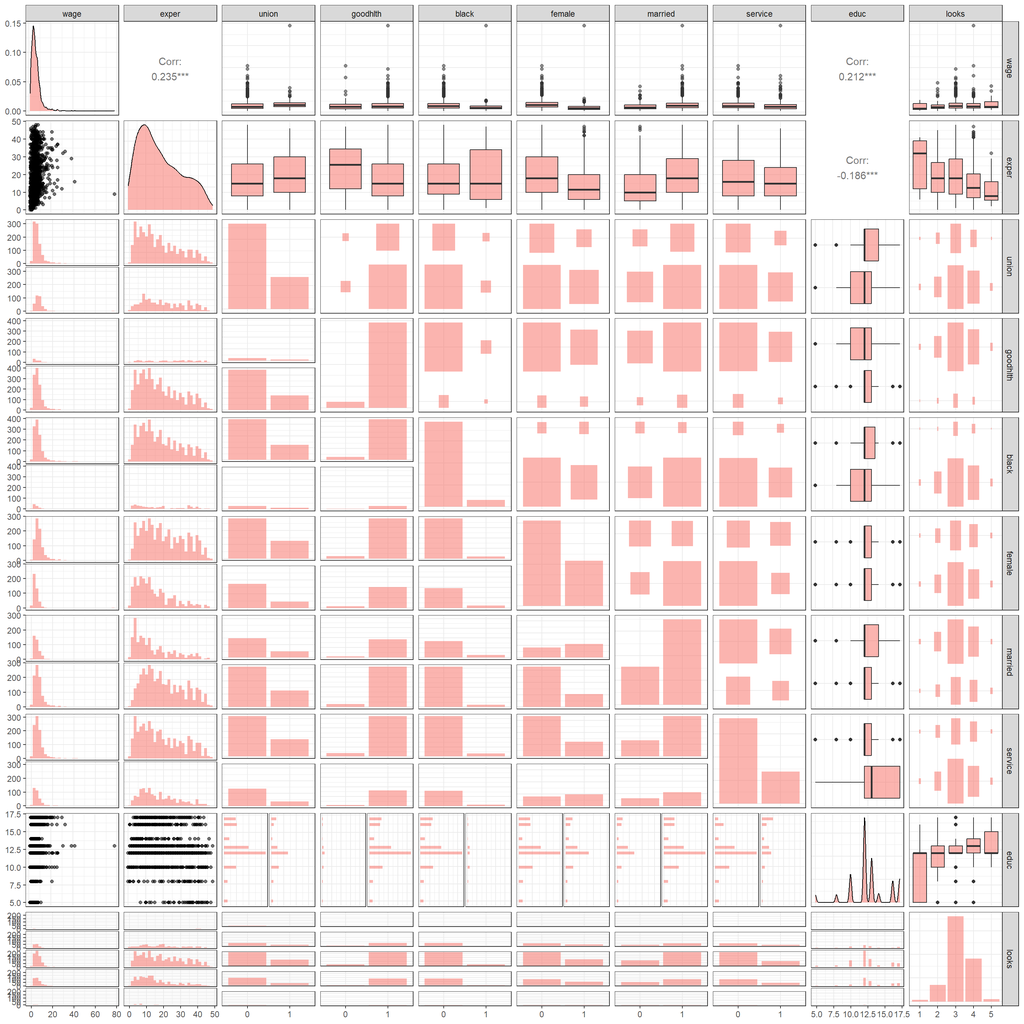

## Solution

### Preprocessing

Histogram of attractiveness:

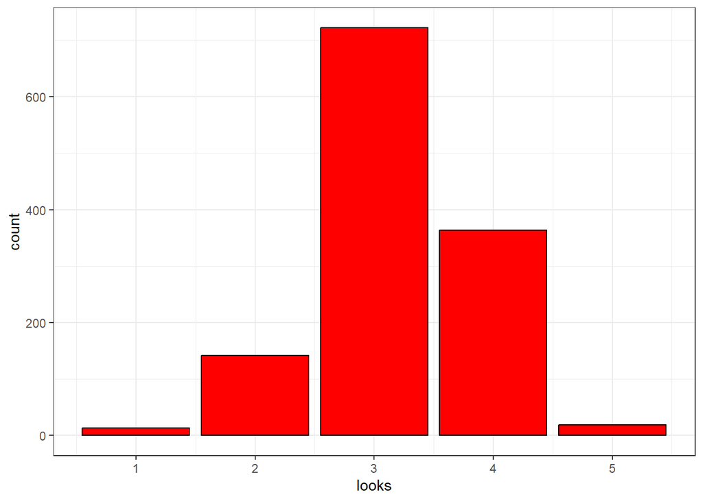

There are just a few observations with looks=1 and looks=5. Let’s transform the looks feature to two binary indicators of being above or below average:

[output not shown]

Distribution of the response variable:

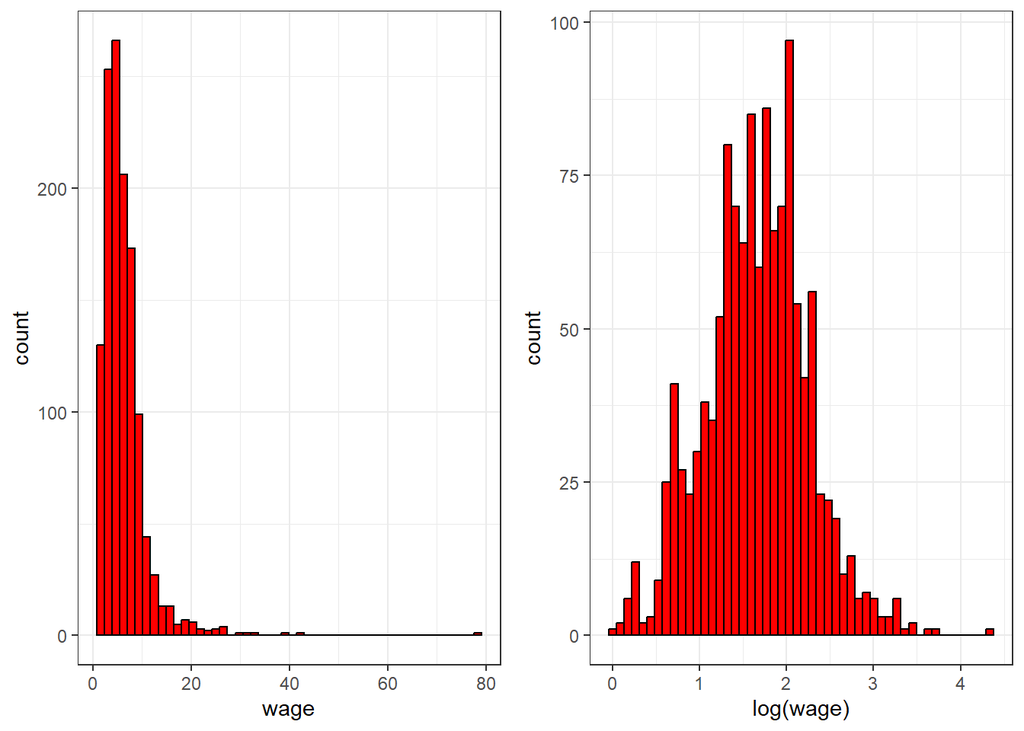

1. One person in the dataset makes 77.72$ per hour, the rest is below 45$; let’s remove this person.
2. $\frac{\max y}{\min y}=$ 40.8529412 $>10$, we need to do Box-Cox transformation:

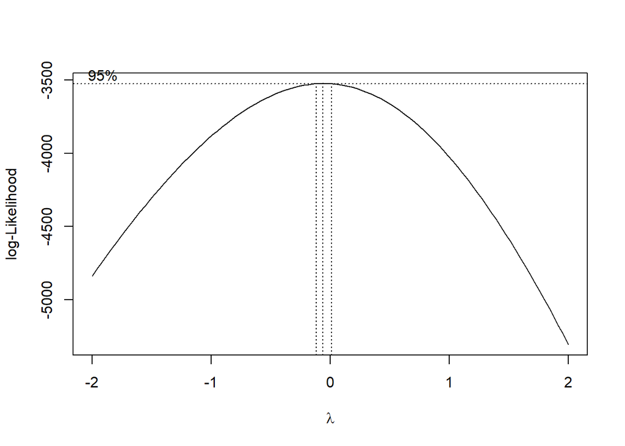

We’ll use $\lambda=0$, meaning that we’ll be modelling the logarithm of the response.

### Model 1

Linear model with all the features.

Residuals visual inspection:

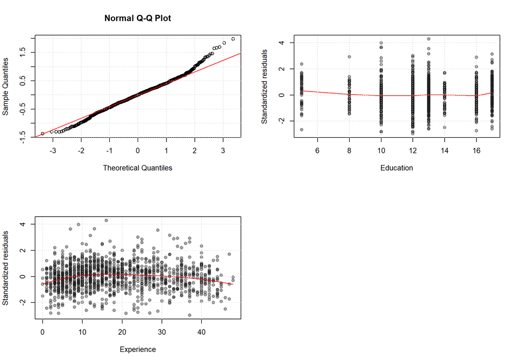

Residuals show the quadratic dependence on the working experience.

### Model 2

Adding to the model the square of working experience.

Visual inspection of the residuals does not provide any insights:

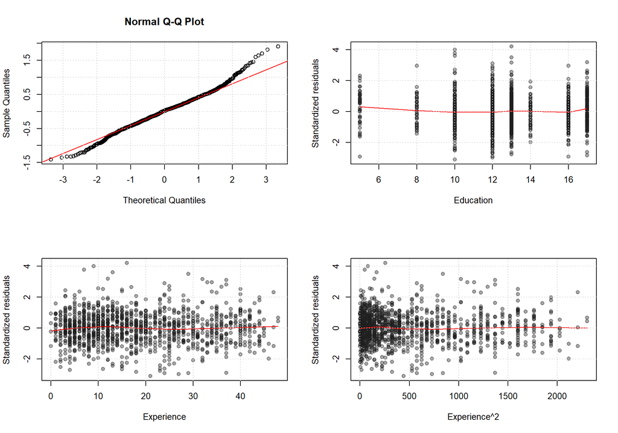

Follow-up tests for the residuals:

| Test | p-value |
| --- | --- |
| Shapiro-Wilk | 1.4071554^{-7} |
| Breusch-Pagan | 4.1925844^{-6} |

They are not normal and heteroscedastic, so we’ll need to use White’s correction as well as adjustment for multiplicity when estimating the significance of the predictors:

```
##
## Call:
## lm(formula = logwage ~ . + I(exper^2), data = data)
##
## Residuals:
##      Min       1Q   Median       3Q      Max
## -1.41092 -0.28236  0.01577  0.26985  1.90502
##
## Coefficients:
##               Estimate Std. Error    t value   Pr(>|t|) Adjusted p-value
## (Intercept)  3.424e-01  9.541e-02  3.588e+00  3.457e-04              NaN
## exper        4.038e-02  4.346e-03  9.290e+00  6.637e-20            0.000
## union        1.710e-01  2.953e-02  5.793e+00  8.733e-09            0.000
## goodhlth     7.159e-02  5.259e-02  1.361e+00  1.737e-01            0.947
## black       -8.310e-02  5.095e-02 -1.631e+00  1.031e-01            0.675
## female      -3.936e-01  3.057e-02 -1.287e+01  1.051e-35            0.000
## married      1.010e-02  3.071e-02  3.290e-01  7.422e-01            1.000
## service     -1.599e-01  3.186e-02 -5.018e+00  5.970e-07            0.000
## educ         7.580e-02  5.437e-03  1.394e+01  3.672e-41            0.000
## aboveavg    -2.487e-03  2.958e-02 -8.407e-02  9.330e-01            1.000
## belowavg    -1.352e-01  4.082e-02 -3.313e+00  9.492e-04            0.007
## I(exper^2)  -6.118e-04  9.634e-05 -6.351e+00  2.996e-10            0.000
##
## Residual standard error: 0.4578 on 1247 degrees of freedom
## Multiple R-squared:  0.4028, Adjusted R-squared:  0.3975
## F-statistic: 76.46 on 11 and 1247 DF,  p-value: < 2.2e-16
```

Non-significant features: health, race, marital status, attractiveness above average. Before removing insignificant features, let’s check if they are part of significant interactions:

```
## Single term additions
##
## Model:
## logwage ~ exper + union + goodhlth + black + female + married +
##     service + educ + aboveavg + belowavg + I(exper^2)
##                     Df Sum of Sq    RSS     AIC F value    Pr(>F)
## <none>                           261.40 -1955.2
## exper:union          1   0.44869 260.95 -1955.3  2.1424 0.1435298
## exper:goodhlth       1   0.00045 261.40 -1953.2  0.0022 0.9628754
## exper:black          1   0.12543 261.28 -1953.8  0.5982 0.4394187
## exper:female         1   2.38436 259.02 -1964.7 11.4699 0.0007294 ***
## exper:married        1   1.12955 260.27 -1958.6  5.4075 0.0202106 *
## exper:service        1   0.93793 260.46 -1957.7  4.4869 0.0343538 *
## exper:educ           1   0.00193 261.40 -1953.2  0.0092 0.9235768
## exper:aboveavg       1   0.01638 261.38 -1953.2  0.0781 0.7799812
## exper:belowavg       1   0.01523 261.39 -1953.2  0.0726 0.7876568
## exper:I(exper^2)     1   0.44697 260.95 -1955.3  2.1342 0.1443004
## union:goodhlth       1   0.17345 261.23 -1954.0  0.8273 0.3632270
## union:black          1   0.00442 261.40 -1953.2  0.0211 0.8846047
## union:female         1   0.36002 261.04 -1954.9  1.7184 0.1901352
## union:married        1   0.04145 261.36 -1953.4  0.1976 0.6567382
## union:service        1   0.00679 261.39 -1953.2  0.0323 0.8573023
## union:educ           1   0.20255 261.20 -1954.1  0.9662 0.3258127
## union:aboveavg       1   0.01096 261.39 -1953.2  0.0522 0.8192470
## union:belowavg       1   0.12107 261.28 -1953.8  0.5774 0.4474952
## union:I(exper^2)     1   0.69193 260.71 -1956.5  3.3069 0.0692283 .
## goodhlth:black       1   0.78641 260.62 -1957.0  3.7598 0.0527241 .
## goodhlth:female      1   0.62287 260.78 -1956.2  2.9760 0.0847533 .
## goodhlth:married     1   0.68083 260.72 -1956.5  3.2537 0.0715036 .
## goodhlth:service     1   0.17097 261.23 -1954.0  0.8155 0.3666825
## goodhlth:educ        1   0.22292 261.18 -1954.2  1.0635 0.3026250
## goodhlth:aboveavg    1   0.44717 260.95 -1955.3  2.1351 0.1442103
## goodhlth:belowavg    1   0.24594 261.16 -1954.3  1.1734 0.2789103
## goodhlth:I(exper^2)  1   0.04039 261.36 -1953.4  0.1926 0.6608580
## black:female         1   2.52500 258.88 -1965.4 12.1531 0.0005071 ***
## black:married        1   0.28758 261.11 -1954.5  1.3723 0.2416410
## black:service        1   0.26454 261.14 -1954.4  1.2622 0.2614438
## black:educ           1   0.09938 261.30 -1953.6  0.4739 0.4913352
## black:aboveavg       1   0.02301 261.38 -1953.3  0.1097 0.7405774
## black:belowavg       1   0.19482 261.21 -1954.1  0.9293 0.3352298
```

[output cut: 9 more lines]

```
## married:aboveavg     1   0.41753 260.98 -1955.2  1.9934 0.1582390
## married:belowavg     1   0.03982 261.36 -1953.4  0.1898 0.6631173
## married:I(exper^2)   1   1.37303 260.03 -1959.8  6.5792 0.0104337 *
## service:educ         1   0.04883 261.35 -1953.4  0.2328 0.6295549
## service:aboveavg     1   0.06057 261.34 -1953.5  0.2888 0.5911112
## service:belowavg     1   0.00144 261.40 -1953.2  0.0069 0.9339333
## service:I(exper^2)   1   0.63868 260.76 -1956.2  3.0518 0.0808946 .
## educ:aboveavg        1   0.04114 261.36 -1953.4  0.1961 0.6579475
## educ:belowavg        1   0.01961 261.38 -1953.3  0.0935 0.7598312
## educ:I(exper^2)      1   0.06610 261.34 -1953.5  0.3152 0.5746347
## aboveavg:belowavg    0   0.00000 261.40 -1955.2
## aboveavg:I(exper^2)  1   0.00002 261.40 -1953.2  0.0001 0.9921716
## belowavg:I(exper^2)  1   0.05738 261.34 -1953.4  0.2736 0.6010267
## ---
## Signif. codes:  0 '***' 0.001 '**' 0.01 '*' 0.05 '.' 0.1 ' ' 1
```

### Model 3

Removing from model 2 all the insignificant predictors and adding the interaction between sex and working experience.

Residuals:

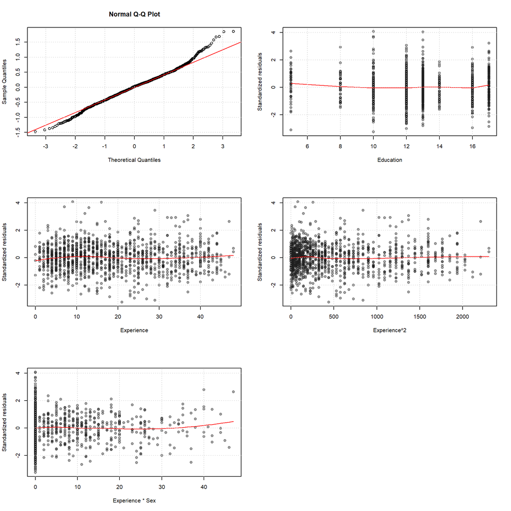

(no insights).

Properties:

| Test | p-value |
| --- | --- |
| Shapiro-Wilk | 3.0075824^{-7} |
| Breusch-Pagan | 3.058155^{-6} |

nonnormal and heteroscedastic. Significance testing with White’s correction and multiplicity adjustment:

```
##
## Call:
## lm(formula = logwage ~ exper + exper * female + female + union +
##     service + educ + aboveavg + belowavg + I(exper^2), data = data)
##
## Residuals:
##      Min       1Q   Median       3Q      Max
## -1.48289 -0.28482  0.01858  0.27788  1.85005
##
## Coefficients:
##                Estimate Std. Error    t value   Pr(>|t|) Adjusted p-value
## (Intercept)   3.126e-01  8.225e-02  3.801e+00  1.511e-04              NaN
## exper         4.681e-02  4.533e-03  1.033e+01  4.750e-24            0.000
## female       -2.607e-01  5.024e-02 -5.189e+00  2.467e-07            0.000
## union         1.719e-01  2.941e-02  5.846e+00  6.431e-09            0.000
## service      -1.607e-01  3.170e-02 -5.071e+00  4.555e-07            0.000
## educ          7.764e-02  5.356e-03  1.450e+01  3.950e-44            0.000
## aboveavg     -3.691e-03  2.944e-02 -1.254e-01  9.002e-01            1.000
## belowavg     -1.337e-01  4.061e-02 -3.292e+00  1.021e-03            0.006
## I(exper^2)   -7.065e-04  9.682e-05 -7.297e+00  5.227e-13            0.000
## exper:female -8.935e-03  2.542e-03 -3.515e+00  4.551e-04            0.010
##
## Residual standard error: 0.4561 on 1249 degrees of freedom
## Multiple R-squared:  0.4064, Adjusted R-squared:  0.4021
## F-statistic:    95 on 9 and 1249 DF,  p-value: < 2.2e-16
```

Davidson-MacKinnon with White’s correction finds model 3 significantly better than model 2:

```
## J test
##
## Model 1: logwage ~ exper + union + goodhlth + black + female + married +
##     service + educ + aboveavg + belowavg + I(exper^2)
## Model 2: logwage ~ exper + exper * female + female + union + service +
##     educ + aboveavg + belowavg + I(exper^2)
##                 Estimate Std. Error t value Pr(>|t|)
## M1 + fitted(M2)  0.97487    0.31301  3.1145 0.001885 **
## M2 + fitted(M1)  0.88205    0.48257  1.8278 0.067817 .
## ---
## Signif. codes:  0 '***' 0.001 '**' 0.01 '*' 0.05 '.' 0.1 ' ' 1
```

### Model 4

Let’s try to keep ethnicity and marital status in model 2, to add their interaction with sex. As in model 3 we’ll use the interaction of sex with working experience, and omit health.

Residuals:

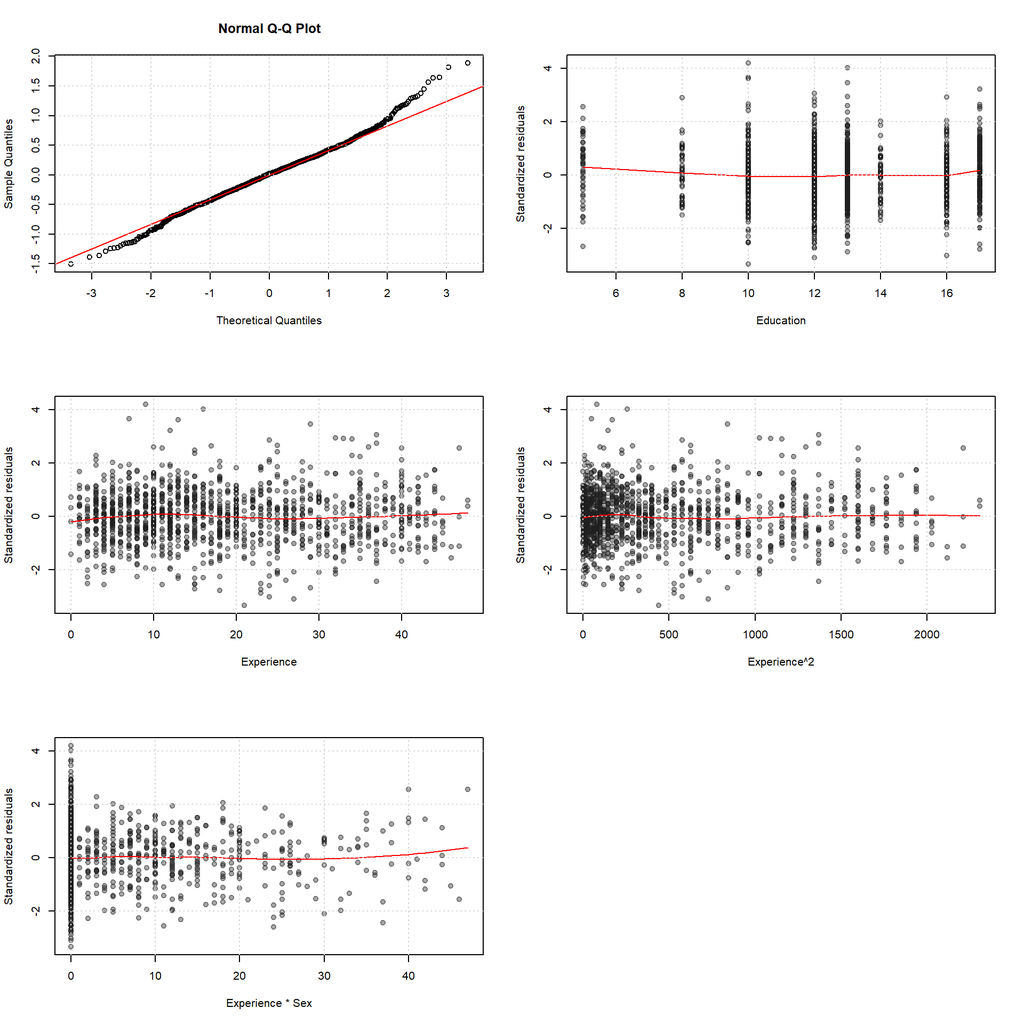

(no insights). Properties:

| Test | p-value |
| --- | --- |
| Shapiro-Wilk | 1.7937774^{-6} |
| Breusch-Pagan | 2.8345252^{-5} |

nonnormal and heteroscedastic. Significance testing with White’s correction and multiplicity adjustment:

```
##
## Call:
## lm(formula = logwage ~ exper + I(exper^2) + exper * female +
##     female + black + female * black + married + female * married +
##     union + service + educ + aboveavg + belowavg, data = data)
##
## Residuals:
##      Min       1Q   Median       3Q      Max
## -1.50715 -0.28320  0.01463  0.27576  1.88275
##
## Coefficients:
##                  Estimate Std. Error    t value   Pr(>|t|) Adjusted p-value
## (Intercept)     3.146e-01  8.558e-02  3.676e+00  2.470e-04              NaN
## exper           4.475e-02  4.689e-03  9.544e+00  7.004e-21            0.000
## I(exper^2)     -6.736e-04  9.846e-05 -6.842e+00  1.225e-11            0.000
## female         -1.954e-01  5.984e-02 -3.266e+00  1.120e-03            0.010
## black          -2.508e-01  7.256e-02 -3.456e+00  5.672e-04            0.006
## married         7.031e-02  4.232e-02  1.661e+00  9.690e-02            0.612
## union           1.782e-01  2.923e-02  6.095e+00  1.453e-09            0.000
## service        -1.603e-01  3.148e-02 -5.093e+00  4.074e-07            0.000
## educ            7.573e-02  5.370e-03  1.410e+01  5.285e-42            0.000
## aboveavg       -1.059e-03  2.927e-02 -3.619e-02  9.711e-01            1.000
## belowavg       -1.353e-01  4.042e-02 -3.348e+00  8.382e-04            0.006
## exper:female   -8.188e-03  2.579e-03 -3.175e+00  1.534e-03            0.036
## female:black    3.295e-01  9.981e-02  3.301e+00  9.899e-04            0.008
## female:married -1.638e-01  6.050e-02 -2.707e+00  6.885e-03            0.052
##
## Residual standard error: 0.4527 on 1245 degrees of freedom
## Multiple R-squared:  0.4172, Adjusted R-squared:  0.4111
## F-statistic: 68.56 on 13 and 1245 DF,  p-value: < 2.2e-16
```

Comparing to model 3 with Wald’s test with White’s correction:

```
## Wald test
##
## Model 1: logwage ~ exper + I(exper^2) + exper * female + female + black +
##     female * black + married + female * married + union + service +
##     educ + aboveavg + belowavg
## Model 2: logwage ~ exper + exper * female + female + union + service +
##     educ + aboveavg + belowavg + I(exper^2)
##   Res.Df Df      F    Pr(>F)
## 1   1245
## 2   1249 -4 6.1382 6.848e-05 ***
## ---
## Signif. codes:  0 '***' 0.001 '**' 0.01 '*' 0.05 '.' 0.1 ' ' 1
```

Model 4 is significantly better.

Do we need to add any other interactions?

```
## Single term additions
##
## Model:
## logwage ~ exper + I(exper^2) + exper * female + female + black +
##     female * black + married + female * married + union + service +
##     educ + aboveavg + belowavg
##                     Df Sum of Sq    RSS     AIC F value  Pr(>F)
## <none>                           255.10 -1981.9
## exper:I(exper^2)     1   0.57827 254.52 -1982.8  2.8264 0.09298 .
## exper:black          1   0.04175 255.05 -1980.1  0.2036 0.65187
## exper:married        1   0.17797 254.92 -1980.8  0.8685 0.35156
## exper:union          1   0.72073 254.38 -1983.5  3.5247 0.06070 .
## exper:service        1   0.46050 254.63 -1982.2  2.2497 0.13389
## exper:educ           1   0.00551 255.09 -1979.9  0.0269 0.86986
## exper:aboveavg       1   0.04164 255.05 -1980.1  0.2031 0.65230
## exper:belowavg       1   0.00288 255.09 -1979.9  0.0141 0.90561
## I(exper^2):female    1   0.11380 254.98 -1980.5  0.5552 0.45634
## I(exper^2):black     1   0.22088 254.88 -1981.0  1.0781 0.29933
## I(exper^2):married   1   0.29017 254.81 -1981.3  1.4166 0.23418
## I(exper^2):union     1   0.88193 254.21 -1984.3  4.3157 0.03797 *
## I(exper^2):service   1   0.32610 254.77 -1981.5  1.5923 0.20724
## I(exper^2):educ      1   0.14825 254.95 -1980.6  0.7234 0.39520
## I(exper^2):aboveavg  1   0.00573 255.09 -1979.9  0.0279 0.86729
## I(exper^2):belowavg  1   0.00062 255.09 -1979.9  0.0030 0.95602
## female:union         1   0.54916 254.55 -1982.6  2.6838 0.10163
## female:service       1   0.74277 254.35 -1983.6  3.6328 0.05688 .
## female:educ          1   0.56298 254.53 -1982.7  2.7515 0.09741 .
## female:aboveavg      1   0.12989 254.97 -1980.5  0.6338 0.42613
## female:belowavg      1   0.01115 255.09 -1980.0  0.0544 0.81562
## black:married        1   0.02461 255.07 -1980.0  0.1200 0.72908
## black:union          1   0.28846 254.81 -1981.3  1.4083 0.23557
## black:service        1   0.00020 255.10 -1979.9  0.0010 0.97492
## black:educ           1   0.30599 254.79 -1981.4  1.4940 0.22183
## black:aboveavg       1   0.00194 255.09 -1979.9  0.0094 0.92259
## black:belowavg       1   0.47605 254.62 -1982.3  2.3258 0.12750
## married:union        1   0.00588 255.09 -1979.9  0.0287 0.86560
## married:service      1   0.17674 254.92 -1980.8  0.8625 0.35322
## married:educ         1   0.22997 254.87 -1981.0  1.1225 0.28960
## married:aboveavg     1   0.25378 254.84 -1981.2  1.2388 0.26591
## married:belowavg     1   0.02162 255.07 -1980.0  0.1055 0.74543
## union:service        1   0.00125 255.09 -1979.9  0.0061 0.93782
## union:educ           1   0.10673 254.99 -1980.4  0.5207 0.47069
## union:aboveavg       1   0.03412 255.06 -1980.1  0.1664 0.68340
## union:belowavg       1   0.09441 255.00 -1980.4  0.4606 0.49747
## service:educ         1   0.09434 255.00 -1980.4  0.4602 0.49765
## service:aboveavg     1   0.04436 255.05 -1980.1  0.2164 0.64191
## service:belowavg     1   0.00307 255.09 -1979.9  0.0150 0.90264
## educ:aboveavg        1   0.03902 255.06 -1980.1  0.1903 0.66273
## educ:belowavg        1   0.05888 255.04 -1980.2  0.2872 0.59211
## aboveavg:belowavg    0   0.00000 255.10 -1981.9
## ---
## Signif. codes:  0 '***' 0.001 '**' 0.01 '*' 0.05 '.' 0.1 ' ' 1
```

Interaction with the square of working experience is difficult to interpret, so let’s not add anything more.

### Model 5

In model 4 marital status and it’s interactions are all insignificant. Let’s see if the model would become significantly worse after deleting both (we’ll use Wald’s test with White’s correction):

```
##
## Call:
## lm(formula = logwage ~ exper + I(exper^2) + exper * female +
##     female + black + female * black + union + service + educ +
##     aboveavg + belowavg, data = data)
##
## Residuals:
##      Min       1Q   Median       3Q      Max
## -1.49535 -0.29037  0.02078  0.27333  1.83344
##
## Coefficients:
##                Estimate Std. Error    t value   Pr(>|t|) Adjusted p-value
## (Intercept)   3.493e-01  8.306e-02  4.205e+00  2.796e-05              NaN
## exper         4.602e-02  4.520e-03  1.018e+01  1.913e-23            0.000
## I(exper^2)   -6.860e-04  9.659e-05 -7.102e+00  2.064e-12            0.000
## female       -2.824e-01  5.043e-02 -5.599e+00  2.656e-08            0.000
## black        -2.677e-01  7.205e-02 -3.715e+00  2.120e-04            0.001
## union         1.780e-01  2.929e-02  6.076e+00  1.630e-09            0.000
## service      -1.587e-01  3.154e-02 -5.030e+00  5.617e-07            0.000
## educ          7.597e-02  5.376e-03  1.413e+01  3.552e-42            0.000
## aboveavg      8.770e-04  2.931e-02  2.993e-02  9.761e-01            1.000
## belowavg     -1.406e-01  4.046e-02 -3.475e+00  5.279e-04            0.004
## exper:female -9.096e-03  2.531e-03 -3.594e+00  3.379e-04            0.007
## female:black  3.600e-01  9.930e-02  3.626e+00  3.000e-04            0.002
##
## Residual standard error: 0.4536 on 1247 degrees of freedom
## Multiple R-squared:  0.4137, Adjusted R-squared:  0.4086
## F-statistic: 80.01 on 11 and 1247 DF,  p-value: < 2.2e-16
```

```
## Wald test
##
## Model 1: logwage ~ exper + I(exper^2) + exper * female + female + black +
##     female * black + married + female * married + union + service +
##     educ + aboveavg + belowavg
## Model 2: logwage ~ exper + I(exper^2) + exper * female + female + black +
##     female * black + union + service + educ + aboveavg + belowavg
##   Res.Df Df      F  Pr(>F)
## 1   1245
## 2   1247 -2 4.0709 0.01729 *
## ---
## Signif. codes:  0 '***' 0.001 '**' 0.01 '*' 0.05 '.' 0.1 ' ' 1
```

Model indeed becomes significantly worse. Let’s try to delete only the interaction of sex and marital status.

```
##
## Call:
## lm(formula = logwage ~ exper + I(exper^2) + exper * female +
##     female + black + female * black + married + union + service +
##     educ + aboveavg + belowavg, data = data)
##
## Residuals:
##      Min       1Q   Median       3Q      Max
## -1.49482 -0.28920  0.01955  0.27611  1.83283
##
## Coefficients:
##                Estimate Std. Error    t value   Pr(>|t|) Adjusted p-value
## (Intercept)   3.537e-01  8.457e-02  4.182e+00  3.092e-05              NaN
## exper         4.634e-02  4.664e-03  9.937e+00  1.922e-22            0.000
## I(exper^2)   -6.913e-04  9.850e-05 -7.018e+00  3.675e-12            0.000
## female       -2.829e-01  5.049e-02 -5.603e+00  2.588e-08            0.000
## black        -2.696e-01  7.241e-02 -3.724e+00  2.052e-04            0.001
## married      -8.572e-03  3.077e-02 -2.786e-01  7.806e-01            1.000
## union         1.780e-01  2.930e-02  6.076e+00  1.635e-09            0.000
## service      -1.586e-01  3.156e-02 -5.026e+00  5.736e-07            0.000
## educ          7.591e-02  5.383e-03  1.410e+01  5.315e-42            0.000
## aboveavg      5.962e-04  2.933e-02  2.032e-02  9.838e-01            1.000
## belowavg     -1.407e-01  4.048e-02 -3.477e+00  5.240e-04            0.004
## exper:female -9.199e-03  2.558e-03 -3.596e+00  3.362e-04            0.008
## female:black  3.608e-01  9.938e-02  3.631e+00  2.940e-04            0.002
##
## Residual standard error: 0.4538 on 1246 degrees of freedom
## Multiple R-squared:  0.4138, Adjusted R-squared:  0.4081
## F-statistic: 73.29 on 12 and 1246 DF,  p-value: < 2.2e-16
```

```
## Wald test
##
## Model 1: logwage ~ exper + I(exper^2) + exper * female + female + black +
##     female * black + married + female * married + union + service +
##     educ + aboveavg + belowavg
## Model 2: logwage ~ exper + I(exper^2) + exper * female + female + black +
##     female * black + married + union + service + educ + aboveavg +
##     belowavg
##   Res.Df Df      F   Pr(>F)
## 1   1245
## 2   1246 -1 8.0259 0.004686 **
## ---
## Signif. codes:  0 '***' 0.001 '**' 0.01 '*' 0.05 '.' 0.1 ' ' 1
```

It gets significantly worse again, and the adjusted R2 gets smaller. We need to get back to model 4.

### Cook’s distance

What are the influential observations?

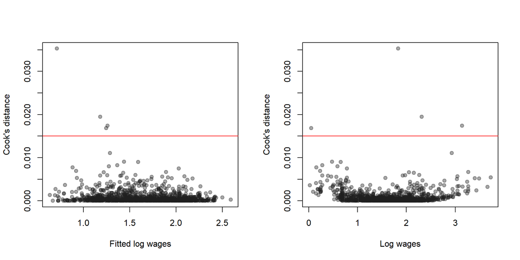

Removing the observations with Cook’s distance above 0.015 (the threshold is chosen by visual inspection) and re-tuning the model 4 on the reduced dataset.

Let’s compare the coefficients of the new model with ones of the original model 4:

```
##                     All data Filtered data
## (Intercept)     0.3145914333   0.265356323
## exper           0.0447480234   0.047405332
## I(exper^2)     -0.0006736416  -0.000728978
## female         -0.1954470198  -0.148434764
## black          -0.2507531071  -0.212021582
## married         0.0703086359   0.081285229
## union           0.1781585550   0.180545883
## service        -0.1603376207  -0.172108720
## educ            0.0757252568   0.077043794
## aboveavg       -0.0010591769  -0.004225053
## belowavg       -0.1353339064  -0.131002707
## exper:female   -0.0081883370  -0.010172001
## female:black    0.3294837001   0.243986129
## female:married -0.1637757690  -0.179333594
```

Some coefficients have changed drastically, which means that the removal of influential observations did make sence.

The residuals of the new model:

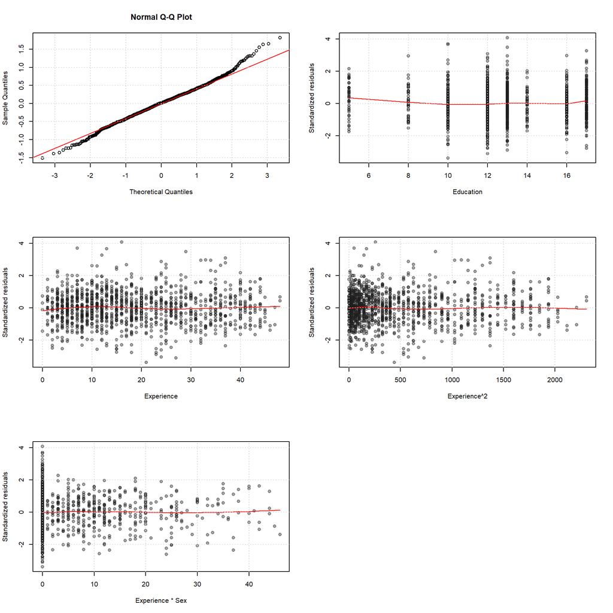

(no insights). Properties:

| Test | p-value |
| --- | --- |
| Shapiro-Wilk | 3.2694944^{-5} |
| Breusch-Pagan | 1.2823034^{-4} |

nonnormal and heteroscedastic. Significance testing with White’s correction and multiplicity adjustment:

```
##
## Call:
## lm(formula = logwage ~ exper + I(exper^2) + exper * female +
##     female + black + female * black + married + female * married +
##     union + service + educ + aboveavg + belowavg, data = data2)
##
## Residuals:
##      Min       1Q   Median       3Q      Max
## -1.51348 -0.27989  0.01137  0.27416  1.81393
##
## Coefficients:
##                  Estimate Std. Error    t value   Pr(>|t|) Adjusted p-value
## (Intercept)     2.654e-01  8.507e-02  3.119e+00  1.854e-03              NaN
## exper           4.741e-02  4.669e-03  1.015e+01  2.524e-23            0.000
## I(exper^2)     -7.290e-04  9.812e-05 -7.429e+00  2.023e-13            0.000
## female         -1.484e-01  5.963e-02 -2.489e+00  1.294e-02            0.070
## black          -2.120e-01  7.234e-02 -2.931e+00  3.442e-03            0.021
## married         8.129e-02  4.185e-02  1.942e+00  5.233e-02            0.341
## union           1.805e-01  2.886e-02  6.257e+00  5.393e-10            0.000
## service        -1.721e-01  3.115e-02 -5.526e+00  3.999e-08            0.000
## educ            7.704e-02  5.323e-03  1.447e+01  5.570e-44            0.000
## aboveavg       -4.225e-03  2.894e-02 -1.460e-01  8.839e-01            1.000
## belowavg       -1.310e-01  3.988e-02 -3.285e+00  1.047e-03            0.009
## exper:female   -1.017e-02  2.591e-03 -3.925e+00  9.136e-05            0.001
## female:black    2.440e-01  9.994e-02  2.441e+00  1.477e-02            0.067
## female:married -1.793e-01  5.979e-02 -2.999e+00  2.760e-03            0.017
##
## Residual standard error: 0.4463 on 1241 degrees of freedom
## Multiple R-squared:  0.4284, Adjusted R-squared:  0.4224
## F-statistic: 71.54 on 13 and 1241 DF,  p-value: < 2.2e-16
```

Could we remove the interaction of sex with race or marital status without significantly worsening the model?

```
##
## Call:
## lm(formula = logwage ~ exper + I(exper^2) + exper * female +
##     female + black + female * married + married + union + service +
##     educ + aboveavg + belowavg, data = data2)
##
## Residuals:
##      Min       1Q   Median       3Q      Max
## -1.51107 -0.28687  0.01251  0.27307  1.81841
##
## Coefficients:
##                  Estimate Std. Error    t value   Pr(>|t|) Adjusted p-value
## (Intercept)     2.490e-01  8.497e-02  2.931e+00  3.445e-03              NaN
## exper           4.759e-02  4.677e-03  1.017e+01  2.078e-23            0.000
## I(exper^2)     -7.371e-04  9.826e-05 -7.501e+00  1.201e-13            0.000
## female         -1.207e-01  5.866e-02 -2.058e+00  3.976e-02            0.224
## black          -8.506e-02  5.039e-02 -1.688e+00  9.162e-02            0.501
## married         9.145e-02  4.173e-02  2.192e+00  2.859e-02            0.175
## union           1.774e-01  2.888e-02  6.143e+00  1.091e-09            0.000
## service        -1.728e-01  3.121e-02 -5.536e+00  3.782e-08            0.000
## educ            7.739e-02  5.332e-03  1.451e+01  3.305e-44            0.000
## aboveavg       -7.912e-03  2.896e-02 -2.732e-01  7.847e-01            1.000
## belowavg       -1.282e-01  3.994e-02 -3.210e+00  1.360e-03            0.011
## exper:female   -1.003e-02  2.596e-03 -3.863e+00  1.177e-04            0.001
## female:married -1.965e-01  5.950e-02 -3.303e+00  9.850e-04            0.005
##
## Residual standard error: 0.4472 on 1242 degrees of freedom
## Multiple R-squared:  0.4256, Adjusted R-squared:  0.4201
## F-statistic:  76.7 on 12 and 1242 DF,  p-value: < 2.2e-16
```

```
## Wald test
##
## Model 1: logwage ~ exper + I(exper^2) + exper * female + female + black +
##     female * black + married + female * married + union + service +
##     educ + aboveavg + belowavg
## Model 2: logwage ~ exper + I(exper^2) + exper * female + female + black +
##     female * married + married + union + service + educ + aboveavg +
##     belowavg
##   Res.Df Df      F   Pr(>F)
## 1   1241
## 2   1242 -1 7.5684 0.006026 **
## ---
## Signif. codes:  0 '***' 0.001 '**' 0.01 '*' 0.05 '.' 0.1 ' ' 1
```

We could not.

## Results

The final model (#6) is build using 1255 of the initial 1260 datapoints; it explains 43% of the variation in the logarithm of the hourly wage:

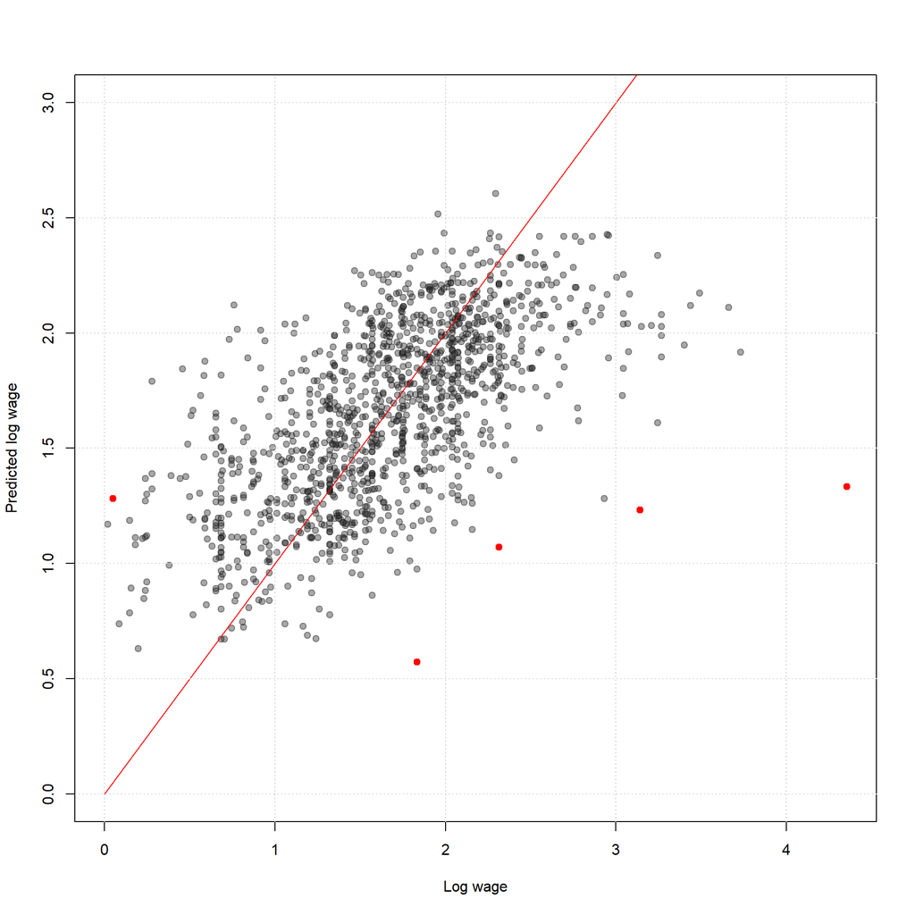

The factors we are interested in - the indicators of attractiveness above and below average - have the following coefficients in the model:

```
##     aboveavg     belowavg
## -0.004225053 -0.131002707
```

```
##                2.5 %      97.5 %
## aboveavg -0.06099884  0.05254873
## belowavg -0.20923385 -0.05277157
```

Adjusting for selected covariates (sex, race, marital status, union membership, indicator of the service industry, working experience, education level), we could conclude that in the population this sample is taken from people with the attractiveness below average earn 13% less (95% confidence interval (5, 21)%, p=0.0010473), and people with attractiveness above average - 0.4% less (95% confidence interval (-5, 6), p=0.8839442). Since the last confidence interval includes 0, we cannot rule out the possibility that being more attractive does not influence the wage at all.

Hamermesh D.S., Biddle J.E. (1994) **Beauty and the Labor Market**, American Economic Review, 84, 1174-1194.